# 五王之战分析 - 冰与火之歌

## 简介

五王之战（War of the Five Kings）是著名严肃奇幻小说《冰与火之歌》中的著名内战。这是一场规模空前、波及七大王国的内乱。顾名思义，前后共有五人在战争中称王：乔佛里、史坦尼斯、蓝礼均声称自己是铁王座的合法继承人。除此之外，罗柏·史塔克被北境众封臣推选为北境之王，巴隆·葛雷乔伊亦再度掀起独立大旗，欲摆脱铁王座的统治，自称为铁群岛之王。

本数据集(battles.csv)包含了五王之战期间的战争，它是所有战斗的大集合。该数据是Kaggle中[Game of Thrones](https://www.kaggle.com/mylesoneill/game-of-thrones)的一部分。

数据中的变量含义解释：

```
name: 战争的名称，字符变量。
year: 战争发生的年份，数值变量。
battle_number: 本数据中的unique id，对应每一场独立的战役，数值变量。
attacker_king: 攻击方的国王，"/"表示了国王的更换。例如："Joffrey/Tommen Baratheon"意味着Tomen Baratheon继承了Joffrey的王位，分类变量。
defender_king: 防守方的国王，分类变量。
attacker_1: 攻击方将领，字符变量。
attacker_2: 攻击方将领，字符变量。
attacker_3: 攻击方将领，字符变量。
attacker_4: 攻击方将领，字符变量。
defender_1: 防守方将领，字符变量。
defender_2: 防守方将领，字符变量。
defender_3: 防守方将领，字符变量。
defender_4: 防守方将领，字符变量。
attacker_outcome: 从攻击方角度来看的战争结果，分别有：win, loss, draw，分类变量。
battle_type: 战争的类别。pitched_battle: 双方军队在一个地点相遇并战斗，这也是最基本的战争类别；ambush: 以隐身或诡计为主要攻击手段的战争；siege: 阵地战；razing: 对未设防位置的攻击。分类变量。
major_death: 是否有重要人物的死亡，二进制变量。
major_capture: 是否有重要人物的被捕，二进制变量。
attacker_size: 攻击方力量的大小，并未对骑兵、步兵等士兵种类有所区分，数值变量。
defender_size: 防守方力量的大小，并未对骑兵、步兵等士兵种类有所区分，数值变量。
attacker_commander: 攻击方的主要指挥官。指挥官的名字中并没有包含头衔，不同的指挥官名字用逗号隔开，字符变量。
defender_commander: 防守方的主要指挥官。指挥官的名字中并没有包含头衔，不同的指挥官名字用逗号隔开，字符变量。
summer: 战争是否发生于夏天，二进制变量。
location: 战争发生的地点，字符变量。
region: 战争发生的地域，包括：Beyond the Wall, The North, The Iron Islands, The Riverlands, The Vale of Arryn, The Westerlands, The Crownlands, The Reach, The Stormlands, Dorne，分类变量。
note: 注释，字符变量。
```

## 项目完成指南

本项目中的数据分析流程已经给出，但代码将完全由你自己进行书写，如果你无法完成本项目，说明你目前的能力并不足以完成 数据分析(进阶)纳米学位，建议先进行 数据分析（入门）纳米学位的学习，掌握进阶课程的先修知识。

对于数据分析过程的记录也是数据分析报告的一个重要部分，你可以自己在需要的位置插入Markdown cell，记录你在数据分析中的关键步骤和推理过程。比如：数据有什么样的特点，统计数据的含义是什么，你从可视化中可以得出什么结论，下一步分析是什么，为什么执行这种分析。如果你无法做到这一点，你也无法通过本项目。

## 提出问题

在此项目中，你将以一名数据分析师的身份执行数据的探索性分析。你将了解数据分析过程的基本流程。在你分析数据之前，请先思考几个你需要理解的关于这些战斗的问题，例如，哪一个区域发生了最多的战争？哪一个国王获得了最多的胜利？战争的胜利与否受那些关键因素的影响？

**问题**：请写下你感兴趣的问题，请确保这些问题能够由现有的数据进行回答。 （为了确保学习的效果，请确保你的数据分析报告中能够包含2幅可视化和1个相关性分析。）

**答案**：

1. 哪一年为战争最多发的年份？
2. 哪一个区域为战争最多发的区域，哪一个区域为战争最稀发的区域？
3. 战争胜利与否与攻击防守方兵力比例没有没有相关性？
4. 在不同的战争类别中，哪一个类别进攻方胜出得最多？

在提出了问题之后，我们将开始导入数据，并对数据进行探索性分析，来回答上面提出的问题。

## 数据评估和清理

```python
# TO DO: load pacakges
import numpy as np # linear algebra
import pandas as pd # data processing, CSV file I/O (e.g. pd.read_csv)
import matplotlib as mpl
import matplotlib.pyplot as plt
import seaborn as sns
```

```python
# TO DO: load the dataset
df = pd.read_csv('battles.csv')
df.head()
```

|  | name | year | battle_number | attacker_king | defender_king | attacker_1 | attacker_2 | attacker_3 | attacker_4 | defender_1 | ... | major_death | major_capture | attacker_size | defender_size | attacker_commander | defender_commander | summer | location | region | note |
| --- | --- | --- | --- | --- | --- | --- | --- | --- | --- | --- | --- | --- | --- | --- | --- | --- | --- | --- | --- | --- | --- |
| 0 | Battle of the Golden Tooth | 298 | 1 | Joffrey/Tommen Baratheon | Robb Stark | Lannister | NaN | NaN | NaN | Tully | ... | 1.0 | 0.0 | 15000.0 | 4000.0 | Jaime Lannister | Clement Piper, Vance | 1.0 | Golden Tooth | The Westerlands | NaN |
| 1 | Battle at the Mummer's Ford | 298 | 2 | Joffrey/Tommen Baratheon | Robb Stark | Lannister | NaN | NaN | NaN | Baratheon | ... | 1.0 | 0.0 | NaN | 120.0 | Gregor Clegane | Beric Dondarrion | 1.0 | Mummer's Ford | The Riverlands | NaN |
| 2 | Battle of Riverrun | 298 | 3 | Joffrey/Tommen Baratheon | Robb Stark | Lannister | NaN | NaN | NaN | Tully | ... | 0.0 | 1.0 | 15000.0 | 10000.0 | Jaime Lannister, Andros Brax | Edmure Tully, Tytos Blackwood | 1.0 | Riverrun | The Riverlands | NaN |
| 3 | Battle of the Green Fork | 298 | 4 | Robb Stark | Joffrey/Tommen Baratheon | Stark | NaN | NaN | NaN | Lannister | ... | 1.0 | 1.0 | 18000.0 | 20000.0 | Roose Bolton, Wylis Manderly, Medger Cerwyn, H... | Tywin Lannister, Gregor Clegane, Kevan Lannist... | 1.0 | Green Fork | The Riverlands | NaN |
| 4 | Battle of the Whispering Wood | 298 | 5 | Robb Stark | Joffrey/Tommen Baratheon | Stark | Tully | NaN | NaN | Lannister | ... | 1.0 | 1.0 | 1875.0 | 6000.0 | Robb Stark, Brynden Tully | Jaime Lannister | 1.0 | Whispering Wood | The Riverlands | NaN |

5 rows × 25 columns

```python
# TO DO: check the dataset general info
print(df.shape)
print(df.info())
```

```
(38, 25)
<class 'pandas.core.frame.DataFrame'>
RangeIndex: 38 entries, 0 to 37
Data columns (total 25 columns):
name                  38 non-null object
year                  38 non-null int64
battle_number         38 non-null int64
attacker_king         36 non-null object
defender_king         35 non-null object
attacker_1            38 non-null object
attacker_2            10 non-null object
attacker_3            3 non-null object
attacker_4            2 non-null object
defender_1            37 non-null object
defender_2            2 non-null object
defender_3            0 non-null float64
defender_4            0 non-null float64
attacker_outcome      37 non-null object
battle_type           37 non-null object
major_death           37 non-null float64
major_capture         37 non-null float64
attacker_size         24 non-null float64
defender_size         19 non-null float64
attacker_commander    37 non-null object
defender_commander    28 non-null object
summer                37 non-null float64
location              37 non-null object
region                38 non-null object
note                  5 non-null object
dtypes: float64(7), int64(2), object(16)
memory usage: 7.5+ KB
None
```

- From above data info, total 38 rows and 25 columns in this dataframe.
- There are missing values for columns 'attacker/defender_king','attacker_2,3,4','defender_1,2,3,4','attacker_outcome','battle_type','major_death','major_capture','attacker/defender_size','attacker/defender_commander','summer', and 'location'.
- No special issue of data types for all variables.

```python
df["note"].unique()
```

```
array([nan,
       "Greyjoy's troop number based on the Battle of Deepwood Motte, in which Asha had 1000 soldier on 30 longships. That comes out to ~33 per longship. In the Battle of the Stony Shore, Theon has 8 longships, and just we can estimate that he has 8*33 =265 troops.",
       "Greyjoy's troop number comes from the 264 estimate to have arrived on the stony shore minus the 20 Theon takes to attack Winterfell. Thus 264-20=244",
       'It isn\'t mentioned how many Stark men are left in Winterfell, other than "very few".',
       "Since House Bolton betrays the Starks for House Lannister, we code this battle as between these two houses. Greyjoy men, numbering only 20, don't play a major part in the fighting and end up dying anyway.",
       'This observation refers to the battle against the Stark men, not the attack on the wedding'],
      dtype=object)
```

- By checking the dataframe info, no data for defender_3 and defender_4, so the corresponding attacker_3 and attacker_4 will also be dropped.
- 'note' can just decribe war, no meaningful data. It is also be dropped.

```python
# TO DO: clean the data
df.drop(['defender_3','defender_4','attacker_3','attacker_4','note'], axis=1, inplace=True)
# check the reivsed columns
df.columns
```

```
Index(['name', 'year', 'battle_number', 'attacker_king', 'defender_king',
       'attacker_1', 'attacker_2', 'defender_1', 'defender_2',
       'attacker_outcome', 'battle_type', 'major_death', 'major_capture',
       'attacker_size', 'defender_size', 'attacker_commander',
       'defender_commander', 'summer', 'location', 'region'],
      dtype='object')
```

```python
df['major_death'].unique()
```

```
array([ 1.,  0., nan])
```

```python
df['major_capture'].unique()
```

```
array([ 0.,  1., nan])
```

```python
df['summer'].unique()
```

```
array([ 1., nan,  0.])
```

```python
# change the value of 'major_death', 'major_capture' and 'summer' to 'Yes' or 'No'
def binary_change(element):
    if element == 1.:
        return "Yes"
    else:
        return "No"
df.loc[:, ["major_death", "major_capture", "summer"]]=df.loc[:, ["major_death", "major_capture", "summer"]].applymap(binary_change)
```

```python
# check the values of corresponding revised columns
df.head()
```

|  | name | year | battle_number | attacker_king | defender_king | attacker_1 | attacker_2 | defender_1 | defender_2 | attacker_outcome | battle_type | major_death | major_capture | attacker_size | defender_size | attacker_commander | defender_commander | summer | location | region |
| --- | --- | --- | --- | --- | --- | --- | --- | --- | --- | --- | --- | --- | --- | --- | --- | --- | --- | --- | --- | --- |
| 0 | Battle of the Golden Tooth | 298 | 1 | Joffrey/Tommen Baratheon | Robb Stark | Lannister | NaN | Tully | NaN | win | pitched battle | Yes | No | 15000.0 | 4000.0 | Jaime Lannister | Clement Piper, Vance | Yes | Golden Tooth | The Westerlands |
| 1 | Battle at the Mummer's Ford | 298 | 2 | Joffrey/Tommen Baratheon | Robb Stark | Lannister | NaN | Baratheon | NaN | win | ambush | Yes | No | NaN | 120.0 | Gregor Clegane | Beric Dondarrion | Yes | Mummer's Ford | The Riverlands |
| 2 | Battle of Riverrun | 298 | 3 | Joffrey/Tommen Baratheon | Robb Stark | Lannister | NaN | Tully | NaN | win | pitched battle | No | Yes | 15000.0 | 10000.0 | Jaime Lannister, Andros Brax | Edmure Tully, Tytos Blackwood | Yes | Riverrun | The Riverlands |
| 3 | Battle of the Green Fork | 298 | 4 | Robb Stark | Joffrey/Tommen Baratheon | Stark | NaN | Lannister | NaN | loss | pitched battle | Yes | Yes | 18000.0 | 20000.0 | Roose Bolton, Wylis Manderly, Medger Cerwyn, H... | Tywin Lannister, Gregor Clegane, Kevan Lannist... | Yes | Green Fork | The Riverlands |
| 4 | Battle of the Whispering Wood | 298 | 5 | Robb Stark | Joffrey/Tommen Baratheon | Stark | Tully | Lannister | NaN | win | ambush | Yes | Yes | 1875.0 | 6000.0 | Robb Stark, Brynden Tully | Jaime Lannister | Yes | Whispering Wood | The Riverlands |

```python
df.drop(index=37, inplace=True)
```

```python
df['attacker_outcome'].unique()
```

```
array(['win', 'loss'], dtype=object)
```

```python
df['battle_type'].unique()
```

```
array(['pitched battle', 'ambush', 'siege', 'razing'], dtype=object)
```

```python
df.shape
```

```
(37, 20)
```

- Number of columns have been reduced from 25 to 20 after data cleansing. In which, columns 'defender_3','defender_4','attacker_3','attacker_4',and 'note' have been dropped due to meaningless data information. Rows have been reduced from 38 to 37. In which, row with attacker_outcome and battle_type of value "NaN" has been dropped.
- The binary value of columns 'major_death', 'major_capture',and 'summer' have been replaced to "Yes" (1) or "No" (0) for easily understanding.

## 数据探索分析

在数据的探索性分析中，请确保你对数据分析中的关键步骤和推理过程进行了记录。你可以自己插入code cell和markdown cell来组织你的报告。

# Which year has most battles?

```python
df_year = df['year'].value_counts()
```

```python
df_year.head()
```

```
299    20
300    10
298     7
Name: year, dtype: int64
```

```python
# In exploratory data analysis, please make sure of using statistics and visualizations
# Create a dataframe for year and the corresponding number of battles per year
year = tuple(df["year"].unique())
nbr_of_battles_year = tuple(df.groupby("year")["year"].count().values)
battle_per_year = pd.DataFrame({"year":year, "number of battles":nbr_of_battles_year}, columns=["year", "number of battles"])
print(battle_per_year)
```

```
   year  number of battles
0   298                  7
1   299                 20
2   300                 10
```

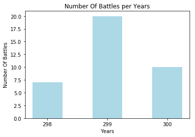

```python
# Plot the graph of nbr of battles in 3 different year respectively
plt.bar([1, 2, 3], nbr_of_battles_year, width=0.5, color='lightblue')
plt.xlabel('Years')
plt.ylabel('Number Of Battles')
plt.xticks([1, 2, 3], ['298', '299', '300'])
plt.title('Number Of Battles per Years');
```

- From above graph, there are most battles in year 299 and least battles in year 298.

# Proportion of the battle region distribution

```python
df['region'].unique()
```

```
array(['The Westerlands', 'The Riverlands', 'The North', 'The Stormlands',
       'The Crownlands', 'Beyond the Wall', 'The Reach'], dtype=object)
```

```python
df_region = df['region'].value_counts()
df_region
```

```
The Riverlands     17
The North           9
The Stormlands      3
The Westerlands     3
The Crownlands      2
The Reach           2
Beyond the Wall     1
Name: region, dtype: int64
```

```python
# Create a dataframe for year and the corresponding number of battles per year
region = tuple(df["region"].unique())
nbr_of_battles_region = tuple(df.groupby("region")["region"].count().values)
battle_per_region = pd.DataFrame({"region":region, "number of battles per region":nbr_of_battles_region}, columns=["region", "number of battles per region"])
battle_per_region = battle_per_region.sort_values(by='number of battles per region',ascending=True)
battle_per_region
```

[output not shown]

[figure not shown]

```python
# Plot the graph of F and M portion
plt.pie([1,2,2,3,3,9,17], labels = ['The Westerlands', 'The Riverlands', 'The Stormlands', 'Beyond the Wall',
       'The Reach', 'The North', 'The Crownlands'], colors = ['skyblue','yellow','pink','lightgreen'],autopct='%.1f%%')
plt.axis('equal')
plt.title('Portion of battles in regions');
```

## Relationship between attacker outcome, attacker and defender size

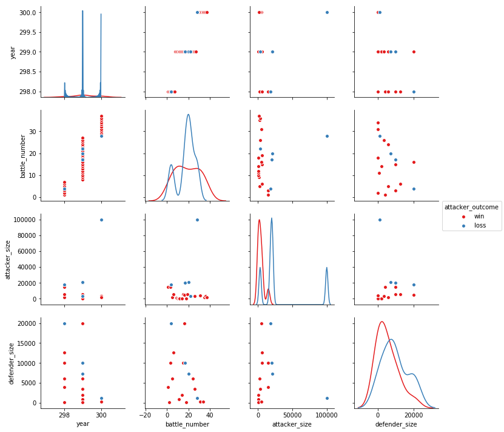

```python
# To check if any relationship between attacker outcome and attacker size / defender size
g = sns.pairplot(df, hue="attacker_outcome", palette="Set1", diag_kind="kde", size=2.5)
```

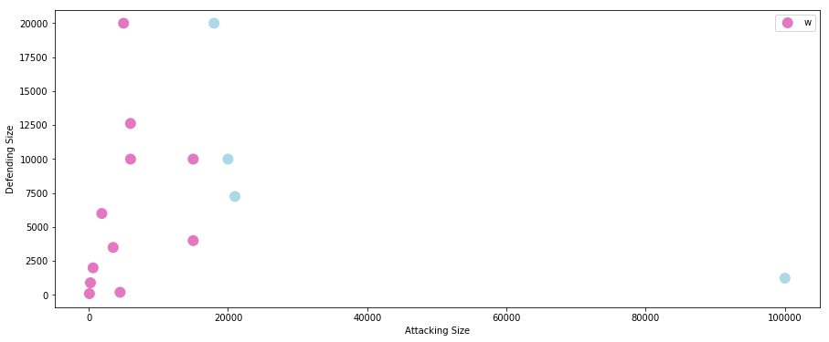

```python
# Plot the graph of attacker size and defender size
data = df.dropna(axis = 0, subset = ["attacker_size", "defender_size", "attacker_outcome"]).copy(deep = True)
col = [sns.color_palette()[6] if x == "win" else "lightblue" for x in data.attacker_outcome.values]
plotdata = data.plot(kind = "scatter", x = "attacker_size", y = "defender_size", c = col, figsize = (15, 6), s = 100, lw = 2.)
_ = plotdata.set_xlabel("Attacking Size"), plotdata.set_ylabel("Defending Size"), plotdata.legend("win")
```

- From above graph, there is no obvious relationship between attacker outcome and attacker/defender size.

## Relationship between attacker outcome and battle type

```python
type_outcome = df.groupby(['battle_type','attacker_outcome']).count()['battle_number']
type_outcome
```

```
battle_type     attacker_outcome
ambush          win                 10
pitched battle  loss                 4
                win                 10
razing          win                  2
siege           loss                 1
                win                 10
Name: battle_number, dtype: int64
```

```
No handles with labels found to put in legend.
```

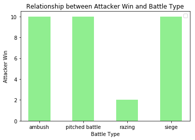

```python
# Plot the graph of show up rate by chronic diseases
plt.legend(bbox_to_anchor=(1,1))

Relationship = [type_outcome['ambush','win'], type_outcome['pitched battle','win'], type_outcome['razing','win'], type_outcome['siege','win']]
plt.bar([1,2,3,4], Relationship, width=0.5, color='lightgreen')
plt.xlabel('Battle Type')
plt.ylabel('Attacker Win')
plt.xticks([1,2,3,4], [ 'ambush','pitched battle','razing','siege'])
plt.title('Relationship between Attacker Win and Battle Type');
```

- From the above graph, razing is the battle type which attacker winned the least.

## 得出结论

**问题**：上面的分析能够回答你提出的问题？通过这些分析你能够得出哪些结论？

## 反思

**问题**：在你的分析和总结过程中是否存在逻辑严谨。是否有改进的空间? 你可以从下面的一些角度进行思考：

1. 数据集是否完整，包含所有想要分析的数据？
2. 在对数据进行处理的时候，你的操作（例如删除/填充缺失值）是否可能影响结论？
3. 是否还有其他变量（本数据中没有）能够对你的分析有帮助？
4. 在得出结论时，你是否混淆了相关性和因果性？

**答案**：

1. 数据集完整，包含了要分析的数据。
2. 在对数据进行处理的时候，对attacker/defender_3/4 及 note 列作了删除。由于defender_3/4 为空值，note为战争描述的文字注释，没有有意义的数据内容，并不会影响结论。另外，基于attacker_outcome 值为空对 attacker_outcome 的最后一行作了删除，基数很小，不足以影响分析结果。因此，综合以上数据清洗的操作，不会影响结论。
3. 还有其他数据可以更深入分析战争，例如每场战争的伤亡人数，被俘虏的人数，都能够对战争规模和战争的结果/影响的相关性分析有帮助。
4. 在得出结论时，分析都是关于相关性，并没有关于因果性的误导。
5. 在sea born 等画图库的运用还在入门摸索阶段，其实可以通过更好的画图技巧展示更多维度，更深入的分析。
6. 在相关性分析当中，可以运用回归分析模型探索各个变量之间的关系。本次的数据源有很多的字符变量，也增加了相关性分析的局限性。

恭喜你完成了此项目！这只是数据分析过程的一个样本：从生成问题、整理数据、探索数据到得出结论。在数据分析(进阶)纳米学位中，你将会学到更多高级的数据分析方法和技术，如果你感兴趣的话，我们鼓励你继续学习后续的课程，掌握更多的数据分析的高级技能！

> 若想与他人分享我们的分析结果，除了向他们提供 jupyter Notebook (.ipynb) 文件的副本外，我们还可以将 Notebook 输出导出为一种甚至那些未安装 Python 的人都能打开的形式。从左上方的“文件”菜单，前往“下载为”子菜单。然后你可以选择一个可以更普遍查看的格式，例如 HTML (.html) 。你可能需要额外软件包或软件来执行这些导出。